# Data Science: Project Report – PJ Paul

# Executive Summary

1. WorldCover’s 2019 survey sample exhibits significant variation in yield rates within and across regions. This suggests a high degree of farmer-level and region-level variability in yields.
2. WorldCover’s insurance policy has an excellent loss ratio of ~70%, and potential for deeper penetration in the Northern and Upper East regions.
3. WorldCover’s policies suffer significantly from basis risk. The probability of a payout being triggered conditional on rain-induced loss is less than 50%.
4. The quality of WorldCover’s 2019 sample data suffers from missing data and potential strategic responses from policy-holders. The high degree of basis risk requires further triangulation using other data sources before it can be confirmed.
5. The existence and extent of basis risk needs to be confirmed and studied as part of urgent further research.

# 1. General context of World Cover operations

## Variation in yield rates in Ghana

Global Yield Gap Atlas estimated Ghanas maize yield to be between 550 - 730 kg per acre. The median for the maximum possible yield as reported by WorldCover’s survey respondents is also around 700 kg per acre. We may then conclude that 700 kg per acre is the upper limit of rainfed maize yield, with 550 kg per acre being a normal rate of yield, and anything below 400 kg per acre being a low rate of yield.

The table below highlights the variation in WorldCover’s telephone survey sample. The variation between regions, as well as within regions is evident. However, these yield figures are affected by weather shocks, and the consequent loss of harvest.

**Region-wise variation in Maize yield**

| Region | Mean yield | Standrd deviation of yield | Coefficient of variation | N |
| --- | --- | --- | --- | --- |
| GH-AH | 324.17 | 167.03 | 1.94 | 35 |
| GH-BA | 277.65 | 118.76 | 2.34 | 37 |
| GH-UW | 320.00 | 179.63 | 1.78 | 9 |
| GH-UE | 190.00 | 127.28 | 1.49 | 4 |
| GH-NP | 236.29 | 169.51 | 1.39 | 164 |

The following table provides harvest-loss adjusted yield-estimated for Maize in WorldCover’s sample. The large coefficient of variation with each loss-category suggests a high degree of variability between farmers in the sample.

**Harvest loss-wise variation in Maize yield**

| Harvest loss % | Mean yield | Standrd deviation of yield | Coefficient of variation | N |
| --- | --- | --- | --- | --- |
| none | 439.29 | 250.77 | 1.75 | 11 |
| 1/4 | 162.88 | 88.84 | 1.83 | 41 |
| 1/3 | 222.65 | 127.87 | 1.74 | 28 |
| 1/2 | 338.97 | 132.30 | 2.56 | 43 |
| 2/3 | 259.09 | 184.44 | 1.40 | 22 |
| 3/4 | 276.91 | 203.98 | 1.36 | 18 |
| all | 66.67 | 76.38 | 0.87 | 3 |
| NA | NaN | NaN | NaN | 83 |

## Factors influencing variation in yield rates

Although there is strong empirical evidence for the effect of individual, and agronomic factors in yield rates generated by farmers, the high rates of missing data in WorldCover’s sample will make it difficult to identify these effects in WorldCover’s sample. However, we can still try and fit a regression model using data on phone, fertiliser usage, acerage planted, and the region of residence.

```
##
## Call:
## lm(formula = ypa ~ cht_phone + fert_bags + planted_acres + reg_nm,
##     data = regression_data)
##
## Residuals:
##     Min      1Q  Median      3Q     Max
## -348.08  -92.62  -28.18   67.91  646.49
##
## Coefficients:
##               Estimate Std. Error t value Pr(>|t|)
## (Intercept)    286.450    121.631   2.355  0.01978 *
## cht_phoneTRUE   24.371    113.720   0.214  0.83059
## fert_bags        8.297      2.560   3.241  0.00146 **
## planted_acres   -9.865      5.195  -1.899  0.05943 .
## reg_nmGH-BA    -21.118     47.895  -0.441  0.65990
## reg_nmGH-NP    -75.811     37.625  -2.015  0.04565 *
## reg_nmGH-UE   -136.071    117.698  -1.156  0.24943
## reg_nmGH-UW    -40.826     88.170  -0.463  0.64399
## ---
## Signif. codes:  0 '***' 0.001 '**' 0.01 '*' 0.05 '.' 0.1 ' ' 1
##
## Residual standard error: 158.8 on 154 degrees of freedom
##   (87 observations deleted due to missingness)
## Multiple R-squared:  0.1041, Adjusted R-squared:  0.06342
## F-statistic: 2.557 on 7 and 154 DF,  p-value: 0.01611
```

| **Characteristic** | **Beta** | **95% CI**<sup>1</sup> | **p-value** |
| --- | --- | --- | --- |
| cht_phone | 24 | -200, 249 | 0.8 |
| fert_bags | 8.3 | 3.2, 13 | 0.001 |
| planted_acres | -9.9 | -20, 0.40 | 0.059 |
| reg_nm |  |  |  |
| GH-AH | — | — |  |
| GH-BA | -21 | -116, 73 | 0.7 |
| GH-NP | -76 | -150, -1.5 | 0.046 |
| GH-UE | -136 | -369, 96 | 0.2 |
| GH-UW | -41 | -215, 133 | 0.6 |

<sup>*1*</sup> CI = Confidence Interval

# 2. Business performance of WC policies

For the 2019 season, WorldCover sold 2279 weather insurance policies for maize. Ghana’s Northern Province was the biggest market for WorldCover’s policies, also the premium amount per policy here was small.

**Region-wise performance of WC policies**

| Region | Policies Sold | Premium Collected | Pay-outs | Net financial position |
| --- | --- | --- | --- | --- |
| GH-NP | 1489 | $2,908.15 | $2,897.58 | $10.58 |
| GH-BA | 319 | $2,918.92 | $1,465.97 | $1,452.94 |
| GH-AH | 248 | $1,945.06 | $895.30 | $1,049.77 |
| GH-UE | 153 | $259.94 | $122.56 | $137.38 |
| GH-UW | 65 | $173.92 | $87.81 | $86.11 |
| GH-TV | 5 | $29.27 | $11.71 | $17.56 |
| Total | 2279 | $8,235.26 | $5,480.92 | $2,754.34 |

Insurance penetration, in relation to cultivated land and fertilizers used also shows differences across regions. The Northern and Upper East provinces seem to be under-penetrated with respect to premium. There is potential for further growth in these regions.

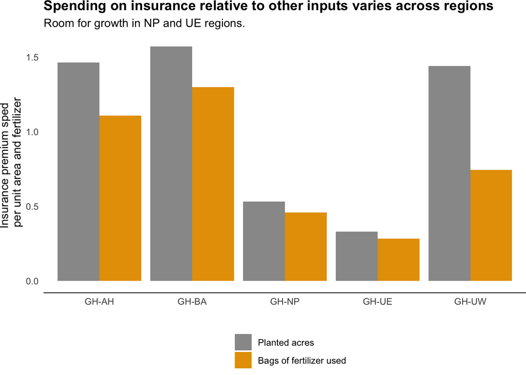

Even though NP and UE regions maybe relatively under-developed, their spending on fertilisers per acre cultivated, and total area cultivated are similar to AH and BA regions. The table below highlights this similarity.

**Region-wise fertilizer usage and area under cultivation**

| Region | Average fertilizer bags per acre | Average acres cultivated | N |
| --- | --- | --- | --- |
| GH-AH | 1.50 | 6.40 | 26 |
| GH-BA | 0.52 | 4.38 | 24 |
| GH-UW | 3.00 | 2.50 | 4 |
| GH-UE | 1.50 | 3.50 | 2 |
| GH-NP | 1.33 | 4.65 | 110 |

# 3. Product performance of WC policies

To continue to maintain tight loss-ratios, while scaling policy volumes, WorldCover will need to keep a tight check on the basis risk involved in their operations. My analysis of the 2019 season’s coverage indicate significant basis risk both in the probability of payouts and the value of payouts. For this analysis, I have assumed the accuracy of the loss rates as reported by WorldCover policy-holders during the telephonic survey. However, there are some suggestions of strategic responses by policy-holders (detailed in Section 4 on Data Quality).

## Basis risk– probability of payouts

**Yield loss-wise payout rates of WC policies**

| Yield lost Proportion | Payout Rate | No of clients reporting loss |
| --- | --- | --- |
| none | 18.2% | 11 |
| 1/4 | 46.3% | 41 |
| 1/3 | 60.7% | 28 |
| 1/2 | 44.2% | 43 |
| 2/3 | 36.4% | 22 |
| 3/4 | 44.4% | 18 |
| all | 33.3% | 3 |

The following graph indicates the basis risk faced by each policy-holder in receving a payout, irrespective of the value of the payout. The graph is created by plotting the percentage of harvest losss as reported by the policy-holder, against a loess estimate of the conditional probability of receiving a payout given the loss suffered. The graph suggests that the probability of receiving a payout if less than 50% in most cases.

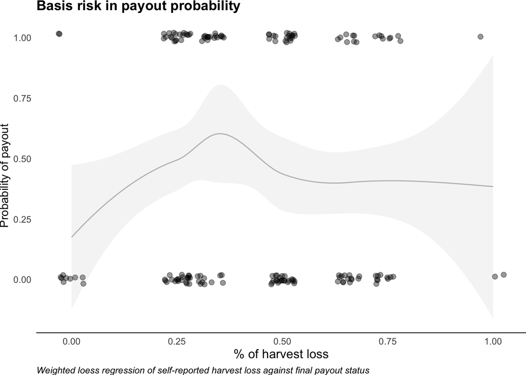

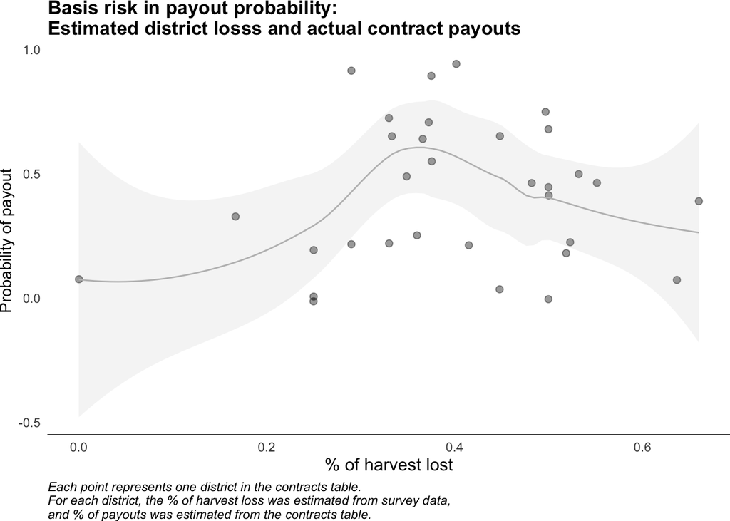

I repeat the same analysis for regional payouts and yield loss averages below. The table below once again suggest that payout rates are not sufficiently sensitive to the reported loss rates.

**Region-wise payout rates of WC policies**

| Region | Policies Sold | Payout Rate | Average yield loss |
| --- | --- | --- | --- |
| GH-NP | 1489 | 55.5% | 40.9% |
| GH-BA | 319 | 23.8% | 51.6% |
| GH-AH | 248 | 18.1% | 47.9% |
| GH-UE | 153 | 28.1% | 41.5% |
| GH-UW | 65 | 52.3% | 33.2% |
| GH-TV | 5 | 40.0% | NA |
| Aggregate | 2279 | 45.1% | 43.4% |

## Basis risk– payout value

For a policy-holder, the actual value of the payout is more important than the mere triggering of a payout. In the following figure, I estimate the market value of lost harvest and compare it to the payout value the policy-holder received. Similar to earlier, I find that the payout value is only a small proportion of the lost value of harvest.

However, I’m not sure if WorldCover policies are entirely reponsible for the gap between payout and loss value we see here. For instance, if policy holders under-insured themselves, this could result in lower values of payouts.

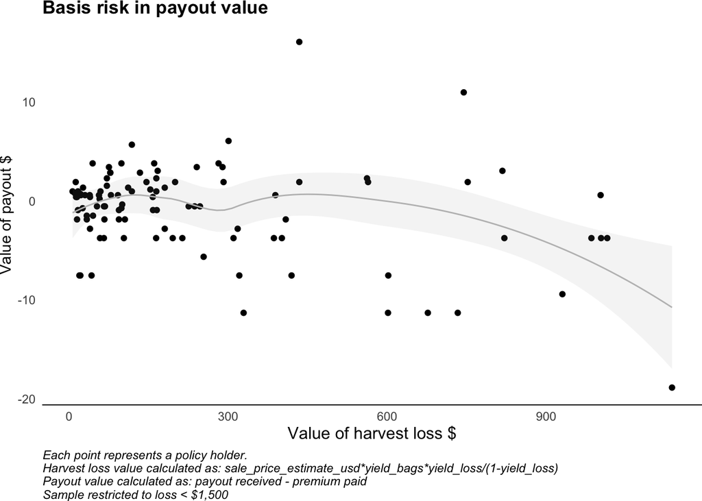

# 4. Note on data quality

The quality of the 2019 sampled data has room for significant improvement. Problems include large levels of missingness in data, potential bias due to survey non-response, and strategic responsses from survey respondents.

- Missing data: Several columsn in the customer table have high degress of missing data.

```
## # A tibble: 13 x 6
##    variables      types   missing_count missing_percent unique_count unique_rate
##    <chr>          <chr>           <int>           <dbl>        <int>       <dbl>
##  1 cust_N         logical           174           100              1     0.00575
##  2 visit_N        logical           174           100              1     0.00575
##  3 is_female      logical           174           100              1     0.00575
##  4 channel_zm     logical           174           100              1     0.00575
##  5 ca_nm          logical           174           100              1     0.00575
##  6 farm_size      numeric           171            98.3            4     0.0230
##  7 num_parcels    numeric           171            98.3            2     0.0115
##  8 call_count     numeric           170            97.7            5     0.0287
##  9 literacy       charac…           136            78.2            3     0.0172
## 10 mm_paid        logical           104            59.8            3     0.0172
## 11 gender         charac…            73            42.0            3     0.0172
## 12 has_mobile_mo… logical            68            39.1            3     0.0172
## 13 notes          charac…            43            24.7           82     0.471
```

| variables | types | missing_count | missing_percent | unique_count | unique_rate |
| --- | --- | --- | --- | --- | --- |
| cust_N | logical | 174 | 100.00000 | 1 | 0.005747126 |
| visit_N | logical | 174 | 100.00000 | 1 | 0.005747126 |
| is_female | logical | 174 | 100.00000 | 1 | 0.005747126 |
| channel_zm | logical | 174 | 100.00000 | 1 | 0.005747126 |
| ca_nm | logical | 174 | 100.00000 | 1 | 0.005747126 |
| farm_size | numeric | 171 | 98.27586 | 4 | 0.022988506 |
| num_parcels | numeric | 171 | 98.27586 | 2 | 0.011494253 |
| call_count | numeric | 170 | 97.70115 | 5 | 0.028735632 |
| literacy | character | 136 | 78.16092 | 3 | 0.017241379 |
| mm_paid | logical | 104 | 59.77011 | 3 | 0.017241379 |
| gender | character | 73 | 41.95402 | 3 | 0.017241379 |
| has_mobile_money | logical | 68 | 39.08046 | 3 | 0.017241379 |
| notes | character | 43 | 24.71264 | 82 | 0.471264368 |

- Non-reponse and recalculating weights: About 30% of the sample did not respond to the phone survey. We should verify if there are systematic patterns in non-response. On first glance however, the data does seem to be balanced across regions at least.

- Strategic reponses to the survey: We can notice that as policy-holders reporting higher fractions of harvest loss, also report higher values of maximum potential yields. This might suggest attempts at strategic responses.

| yield_lost_factor | mean_yield_max | sd | n | cov |
| --- | --- | --- | --- | --- |
| none | NA | NA | 11 | NA |
| 1/4 | 719.4106 | 282.0129 | 41 | 2.550984 |
| 1/3 | 683.8095 | 332.2262 | 28 | 2.058265 |
| 1/2 | 749.7433 | 224.0168 | 43 | 3.346817 |
| 2/3 | 686.0931 | 217.8593 | 22 | 3.149249 |
| 3/4 | 985.5820 | 438.2571 | 18 | 2.248867 |
| all | 1005.5556 | 437.9033 | 3 | 2.296296 |
| NA | NA | NA | 83 | NA |

# 5. Questions for further research: Basis Risk

Without doubt, the question of basis risk needs to be researched further. The reported harvest losses must be confirmed via alternate data sources. If basis risk is revealed to be a strong presence, the next step should be to understand why WorldCover’s algorithms were unable to identify the harvest losses, and to remedy such faults.